# Risk Factor Analysis

## Outcome Variable

**Outcome Variable:** ever_stunted

## Predictor Variables

**Intervention Variable:** parity

**Adjustment Set:**

unadjusted

## Stratifying Variables

The analysis was stratified on these variable(s):

- agecat
- studyid
- country

## Data Summary

| agecat | studyid | country | parity | ever_stunted | n_cell | n |
| --- | --- | --- | --- | --- | --- | --- |
| 0-24 months | ki1000304b-SAS-CompFeed | INDIA | 1 | 0 | 162 | 1533 |
| 0-24 months | ki1000304b-SAS-CompFeed | INDIA | 1 | 1 | 290 | 1533 |
| 0-24 months | ki1000304b-SAS-CompFeed | INDIA | 2 | 0 | 122 | 1533 |
| 0-24 months | ki1000304b-SAS-CompFeed | INDIA | 2 | 1 | 238 | 1533 |
| 0-24 months | ki1000304b-SAS-CompFeed | INDIA | 3+ | 0 | 189 | 1533 |
| 0-24 months | ki1000304b-SAS-CompFeed | INDIA | 3+ | 1 | 532 | 1533 |
| 0-24 months | ki1000304b-SAS-FoodSuppl | INDIA | 1 | 0 | 19 | 397 |
| 0-24 months | ki1000304b-SAS-FoodSuppl | INDIA | 1 | 1 | 58 | 397 |
| 0-24 months | ki1000304b-SAS-FoodSuppl | INDIA | 2 | 0 | 12 | 397 |
| 0-24 months | ki1000304b-SAS-FoodSuppl | INDIA | 2 | 1 | 80 | 397 |
| 0-24 months | ki1000304b-SAS-FoodSuppl | INDIA | 3+ | 0 | 28 | 397 |
| 0-24 months | ki1000304b-SAS-FoodSuppl | INDIA | 3+ | 1 | 200 | 397 |
| 0-24 months | ki1017093b-PROVIDE | BANGLADESH | 1 | 0 | 154 | 700 |
| 0-24 months | ki1017093b-PROVIDE | BANGLADESH | 1 | 1 | 117 | 700 |
| 0-24 months | ki1017093b-PROVIDE | BANGLADESH | 2 | 0 | 134 | 700 |
| 0-24 months | ki1017093b-PROVIDE | BANGLADESH | 2 | 1 | 110 | 700 |
| 0-24 months | ki1017093b-PROVIDE | BANGLADESH | 3+ | 0 | 108 | 700 |
| 0-24 months | ki1017093b-PROVIDE | BANGLADESH | 3+ | 1 | 77 | 700 |
| 0-24 months | ki1066203-TanzaniaChild2 | TANZANIA, UNITED REPUBLIC OF | 1 | 0 | 550 | 2357 |
| 0-24 months | ki1066203-TanzaniaChild2 | TANZANIA, UNITED REPUBLIC OF | 1 | 1 | 271 | 2357 |
| 0-24 months | ki1066203-TanzaniaChild2 | TANZANIA, UNITED REPUBLIC OF | 2 | 0 | 494 | 2357 |
| 0-24 months | ki1066203-TanzaniaChild2 | TANZANIA, UNITED REPUBLIC OF | 2 | 1 | 277 | 2357 |
| 0-24 months | ki1066203-TanzaniaChild2 | TANZANIA, UNITED REPUBLIC OF | 3+ | 0 | 495 | 2357 |
| 0-24 months | ki1066203-TanzaniaChild2 | TANZANIA, UNITED REPUBLIC OF | 3+ | 1 | 270 | 2357 |
| 0-24 months | ki1101329-Keneba | GAMBIA | 1 | 0 | 119 | 1990 |
| 0-24 months | ki1101329-Keneba | GAMBIA | 1 | 1 | 122 | 1990 |
| 0-24 months | ki1101329-Keneba | GAMBIA | 2 | 0 | 110 | 1990 |
| 0-24 months | ki1101329-Keneba | GAMBIA | 2 | 1 | 104 | 1990 |
| 0-24 months | ki1101329-Keneba | GAMBIA | 3+ | 0 | 632 | 1990 |
| 0-24 months | ki1101329-Keneba | GAMBIA | 3+ | 1 | 903 | 1990 |

[output cut: 168 more lines]

The following strata were considered:

- agecat: 0-24 months, studyid: ki1000304b-SAS-CompFeed, country: INDIA
- agecat: 0-24 months, studyid: ki1000304b-SAS-FoodSuppl, country: INDIA
- agecat: 0-24 months, studyid: ki1017093b-PROVIDE, country: BANGLADESH
- agecat: 0-24 months, studyid: ki1066203-TanzaniaChild2, country: TANZANIA, UNITED REPUBLIC OF
- agecat: 0-24 months, studyid: ki1101329-Keneba, country: GAMBIA
- agecat: 0-24 months, studyid: ki1113344-GMS-Nepal, country: NEPAL
- agecat: 0-24 months, studyid: ki1126311-ZVITAMBO, country: ZIMBABWE
- agecat: 0-24 months, studyid: ki1135781-COHORTS, country: GUATEMALA
- agecat: 0-24 months, studyid: ki1135781-COHORTS, country: INDIA
- agecat: 0-24 months, studyid: ki1135781-COHORTS, country: PHILIPPINES
- agecat: 0-24 months, studyid: kiGH5241-JiVitA-3, country: BANGLADESH
- agecat: 0-6 months, studyid: ki1000304b-SAS-CompFeed, country: INDIA
- agecat: 0-6 months, studyid: ki1000304b-SAS-FoodSuppl, country: INDIA
- agecat: 0-6 months, studyid: ki1017093b-PROVIDE, country: BANGLADESH
- agecat: 0-6 months, studyid: ki1066203-TanzaniaChild2, country: TANZANIA, UNITED REPUBLIC OF
- agecat: 0-6 months, studyid: ki1101329-Keneba, country: GAMBIA
- agecat: 0-6 months, studyid: ki1113344-GMS-Nepal, country: NEPAL
- agecat: 0-6 months, studyid: ki1126311-ZVITAMBO, country: ZIMBABWE
- agecat: 0-6 months, studyid: ki1135781-COHORTS, country: GUATEMALA
- agecat: 0-6 months, studyid: ki1135781-COHORTS, country: INDIA
- agecat: 0-6 months, studyid: ki1135781-COHORTS, country: PHILIPPINES
- agecat: 0-6 months, studyid: kiGH5241-JiVitA-3, country: BANGLADESH
- agecat: 6-24 months, studyid: ki1000304b-SAS-CompFeed, country: INDIA
- agecat: 6-24 months, studyid: ki1000304b-SAS-FoodSuppl, country: INDIA
- agecat: 6-24 months, studyid: ki1017093b-PROVIDE, country: BANGLADESH
- agecat: 6-24 months, studyid: ki1066203-TanzaniaChild2, country: TANZANIA, UNITED REPUBLIC OF
- agecat: 6-24 months, studyid: ki1101329-Keneba, country: GAMBIA
- agecat: 6-24 months, studyid: ki1113344-GMS-Nepal, country: NEPAL
- agecat: 6-24 months, studyid: ki1126311-ZVITAMBO, country: ZIMBABWE
- agecat: 6-24 months, studyid: ki1135781-COHORTS, country: GUATEMALA
- agecat: 6-24 months, studyid: ki1135781-COHORTS, country: INDIA
- agecat: 6-24 months, studyid: ki1135781-COHORTS, country: PHILIPPINES
- agecat: 6-24 months, studyid: kiGH5241-JiVitA-3, country: BANGLADESH

## Methods Detail

We’re interested in the causal parameters $E[Y_a]$ for all values of $a \in \mathcal{A}$. These parameters represent the mean outcome if, possibly contrary to fact, we intervened to set all units to have $A=a$. Under the randomization and positivity assumptions, these are identified by the statistical parameters $\psi_a=E_W[E_{Y|A,W}(Y|A=a,W)]$. In addition, we’re interested in the mean of $Y$, $E[Y]$ under no intervention (the observed mean). We will estimate these parameters by using SuperLearner to fit the relevant likelihood factors – $E_{Y|A,W}(Y|A=a,W)$ and $p(A=a|W)$, and then updating our likelihood fit using a joint TMLE.

For unadjusted analyses ($W=\{\}$), initial likelihoods were estimated using Lrnr_glm to estimate the simple $E(Y|A)$ and Lrnr_mean to estimate $p(A)$. For adjusted analyses, a small library containing Lrnr_glmnet, Lrnr_xgboost, and Lrnr_mean was used.

Having estimated these parameters, we will then use the delta method to estimate relative risks and attributable risks relative to a prespecified baseline level of $A$.

# Results Detail

## Results Plots

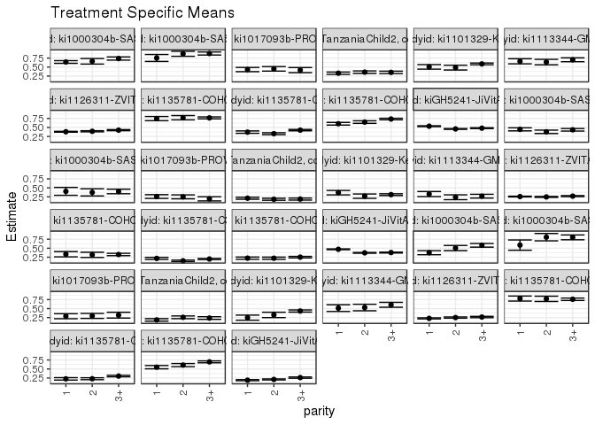

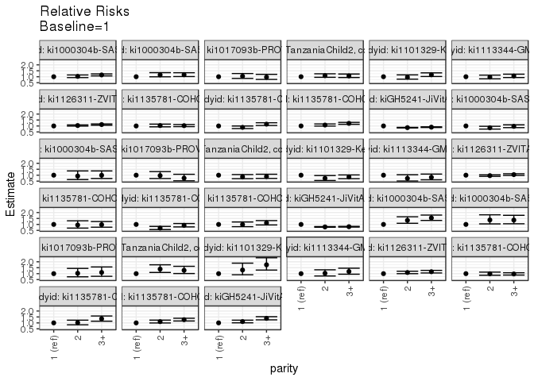

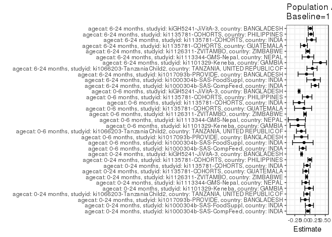

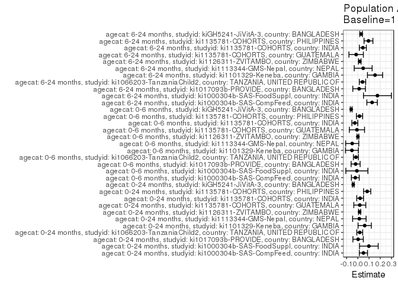

## Results Table

### Parameter: TSM

| agecat | studyid | country | intervention_level | baseline_level | estimate | ci_lower | ci_upper |
| --- | --- | --- | --- | --- | --- | --- | --- |
| 0-24 months | ki1000304b-SAS-CompFeed | INDIA | 1 | NA | 0.6415929 | 0.6043150 | 0.6788709 |
| 0-24 months | ki1000304b-SAS-CompFeed | INDIA | 2 | NA | 0.6611111 | 0.5839267 | 0.7382956 |
| 0-24 months | ki1000304b-SAS-CompFeed | INDIA | 3+ | NA | 0.7378641 | 0.6940814 | 0.7816467 |
| 0-24 months | ki1000304b-SAS-FoodSuppl | INDIA | 1 | NA | 0.7532468 | 0.6568305 | 0.8496631 |
| 0-24 months | ki1000304b-SAS-FoodSuppl | INDIA | 2 | NA | 0.8695652 | 0.8006604 | 0.9384700 |
| 0-24 months | ki1000304b-SAS-FoodSuppl | INDIA | 3+ | NA | 0.8771930 | 0.8345363 | 0.9198497 |
| 0-24 months | ki1017093b-PROVIDE | BANGLADESH | 1 | NA | 0.4317343 | 0.3727199 | 0.4907487 |
| 0-24 months | ki1017093b-PROVIDE | BANGLADESH | 2 | NA | 0.4508197 | 0.3883423 | 0.5132970 |
| 0-24 months | ki1017093b-PROVIDE | BANGLADESH | 3+ | NA | 0.4162162 | 0.3451345 | 0.4872980 |
| 0-24 months | ki1066203-TanzaniaChild2 | TANZANIA, UNITED REPUBLIC OF | 1 | NA | 0.3300853 | 0.2979123 | 0.3622583 |
| 0-24 months | ki1066203-TanzaniaChild2 | TANZANIA, UNITED REPUBLIC OF | 2 | NA | 0.3592737 | 0.3254000 | 0.3931473 |
| 0-24 months | ki1066203-TanzaniaChild2 | TANZANIA, UNITED REPUBLIC OF | 3+ | NA | 0.3529412 | 0.3190698 | 0.3868125 |
| 0-24 months | ki1101329-Keneba | GAMBIA | 1 | NA | 0.5062241 | 0.4430869 | 0.5693612 |
| 0-24 months | ki1101329-Keneba | GAMBIA | 2 | NA | 0.4859813 | 0.4190006 | 0.5529620 |
| 0-24 months | ki1101329-Keneba | GAMBIA | 3+ | NA | 0.5882736 | 0.5636474 | 0.6128998 |
| 0-24 months | ki1113344-GMS-Nepal | NEPAL | 1 | NA | 0.6608187 | 0.5898008 | 0.7318367 |
| 0-24 months | ki1113344-GMS-Nepal | NEPAL | 2 | NA | 0.6387097 | 0.5630224 | 0.7143970 |
| 0-24 months | ki1113344-GMS-Nepal | NEPAL | 3+ | NA | 0.7028986 | 0.6489409 | 0.7568562 |
| 0-24 months | ki1126311-ZVITAMBO | ZIMBABWE | 1 | NA | 0.3806856 | 0.3684681 | 0.3929030 |
| 0-24 months | ki1126311-ZVITAMBO | ZIMBABWE | 2 | NA | 0.3938746 | 0.3791183 | 0.4086310 |
| 0-24 months | ki1126311-ZVITAMBO | ZIMBABWE | 3+ | NA | 0.4251055 | 0.4093703 | 0.4408407 |
| 0-24 months | ki1135781-COHORTS | GUATEMALA | 1 | NA | 0.7464789 | 0.6880357 | 0.8049221 |
| 0-24 months | ki1135781-COHORTS | GUATEMALA | 2 | NA | 0.7708333 | 0.7113612 | 0.8303054 |
| 0-24 months | ki1135781-COHORTS | GUATEMALA | 3+ | NA | 0.7664921 | 0.7396504 | 0.7933339 |
| 0-24 months | ki1135781-COHORTS | INDIA | 1 | NA | 0.3706897 | 0.3374654 | 0.4039139 |
| 0-24 months | ki1135781-COHORTS | INDIA | 2 | NA | 0.3274262 | 0.3007046 | 0.3541478 |
| 0-24 months | ki1135781-COHORTS | INDIA | 3+ | NA | 0.4261299 | 0.4072392 | 0.4450206 |
| 0-24 months | ki1135781-COHORTS | PHILIPPINES | 1 | NA | 0.6032448 | 0.5664139 | 0.6400757 |
| 0-24 months | ki1135781-COHORTS | PHILIPPINES | 2 | NA | 0.6492754 | 0.6136637 | 0.6848870 |
| 0-24 months | ki1135781-COHORTS | PHILIPPINES | 3+ | NA | 0.7349112 | 0.7138643 | 0.7559582 |

[output cut: 69 more lines]

### Parameter: E(Y)

| agecat | studyid | country | intervention_level | baseline_level | estimate | ci_lower | ci_upper |
| --- | --- | --- | --- | --- | --- | --- | --- |
| 0-24 months | ki1000304b-SAS-CompFeed | INDIA | NA | NA | 0.6914547 | 0.6510509 | 0.7318584 |
| 0-24 months | ki1000304b-SAS-FoodSuppl | INDIA | NA | NA | 0.8513854 | 0.8163510 | 0.8864198 |
| 0-24 months | ki1017093b-PROVIDE | BANGLADESH | NA | NA | 0.4342857 | 0.3975409 | 0.4710305 |
| 0-24 months | ki1066203-TanzaniaChild2 | TANZANIA, UNITED REPUBLIC OF | NA | NA | 0.3470513 | 0.3278294 | 0.3662733 |
| 0-24 months | ki1101329-Keneba | GAMBIA | NA | NA | 0.5673367 | 0.5455633 | 0.5891101 |
| 0-24 months | ki1113344-GMS-Nepal | NEPAL | NA | NA | 0.6744186 | 0.6369554 | 0.7118819 |
| 0-24 months | ki1126311-ZVITAMBO | ZIMBABWE | NA | NA | 0.3966032 | 0.3885203 | 0.4046860 |
| 0-24 months | ki1135781-COHORTS | GUATEMALA | NA | NA | 0.7639706 | 0.7413939 | 0.7865473 |
| 0-24 months | ki1135781-COHORTS | INDIA | NA | NA | 0.3911447 | 0.3770865 | 0.4052029 |
| 0-24 months | ki1135781-COHORTS | PHILIPPINES | NA | NA | 0.6863963 | 0.6699497 | 0.7028430 |
| 0-24 months | kiGH5241-JiVitA-3 | BANGLADESH | NA | NA | 0.4938812 | 0.4860382 | 0.5017241 |
| 0-6 months | ki1000304b-SAS-CompFeed | INDIA | NA | NA | 0.4254902 | 0.3977202 | 0.4532601 |
| 0-6 months | ki1000304b-SAS-FoodSuppl | INDIA | NA | NA | 0.3939394 | 0.3457532 | 0.4421255 |
| 0-6 months | ki1017093b-PROVIDE | BANGLADESH | NA | NA | 0.2385714 | 0.2069753 | 0.2701675 |
| 0-6 months | ki1066203-TanzaniaChild2 | TANZANIA, UNITED REPUBLIC OF | NA | NA | 0.1947391 | 0.1787488 | 0.2107293 |
| 0-6 months | ki1101329-Keneba | GAMBIA | NA | NA | 0.3135456 | 0.2924164 | 0.3346748 |
| 0-6 months | ki1113344-GMS-Nepal | NEPAL | NA | NA | 0.2774086 | 0.2416141 | 0.3132032 |
| 0-6 months | ki1126311-ZVITAMBO | ZIMBABWE | NA | NA | 0.2580071 | 0.2507721 | 0.2652422 |
| 0-6 months | ki1135781-COHORTS | GUATEMALA | NA | NA | 0.3253896 | 0.2975756 | 0.3532035 |
| 0-6 months | ki1135781-COHORTS | INDIA | NA | NA | 0.1902526 | 0.1787489 | 0.2017563 |
| 0-6 months | ki1135781-COHORTS | PHILIPPINES | NA | NA | 0.2390451 | 0.2239262 | 0.2541640 |
| 0-6 months | kiGH5241-JiVitA-3 | BANGLADESH | NA | NA | 0.4108676 | 0.4034192 | 0.4183159 |
| 6-24 months | ki1000304b-SAS-CompFeed | INDIA | NA | NA | 0.5030750 | 0.4588491 | 0.5473009 |
| 6-24 months | ki1000304b-SAS-FoodSuppl | INDIA | NA | NA | 0.7615063 | 0.7073642 | 0.8156483 |
| 6-24 months | ki1017093b-PROVIDE | BANGLADESH | NA | NA | 0.2997812 | 0.2577294 | 0.3418330 |
| 6-24 months | ki1066203-TanzaniaChild2 | TANZANIA, UNITED REPUBLIC OF | NA | NA | 0.2276474 | 0.2069456 | 0.2483493 |
| 6-24 months | ki1101329-Keneba | GAMBIA | NA | NA | 0.4014652 | 0.3754511 | 0.4274793 |
| 6-24 months | ki1113344-GMS-Nepal | NEPAL | NA | NA | 0.5610329 | 0.5138522 | 0.6082135 |
| 6-24 months | ki1126311-ZVITAMBO | ZIMBABWE | NA | NA | 0.2458522 | 0.2363900 | 0.2553144 |
| 6-24 months | ki1135781-COHORTS | GUATEMALA | NA | NA | 0.7642458 | 0.7364214 | 0.7920702 |
| 6-24 months | ki1135781-COHORTS | INDIA | NA | NA | 0.2705750 | 0.2559548 | 0.2851951 |
| 6-24 months | ki1135781-COHORTS | PHILIPPINES | NA | NA | 0.6449788 | 0.6246093 | 0.6653483 |
| 6-24 months | kiGH5241-JiVitA-3 | BANGLADESH | NA | NA | 0.2172797 | 0.2079084 | 0.2266510 |

### Parameter: RR

| agecat | studyid | country | intervention_level | baseline_level | estimate | ci_lower | ci_upper |
| --- | --- | --- | --- | --- | --- | --- | --- |
| 0-24 months | ki1000304b-SAS-CompFeed | INDIA | 1 | 1 | 1.0000000 | 1.0000000 | 1.0000000 |
| 0-24 months | ki1000304b-SAS-CompFeed | INDIA | 2 | 1 | 1.0304215 | 0.9250059 | 1.1478503 |
| 0-24 months | ki1000304b-SAS-CompFeed | INDIA | 3+ | 1 | 1.1500502 | 1.0703796 | 1.2356509 |
| 0-24 months | ki1000304b-SAS-FoodSuppl | INDIA | 1 | 1 | 1.0000000 | 1.0000000 | 1.0000000 |
| 0-24 months | ki1000304b-SAS-FoodSuppl | INDIA | 2 | 1 | 1.1544228 | 0.9930811 | 1.3419769 |
| 0-24 months | ki1000304b-SAS-FoodSuppl | INDIA | 3+ | 1 | 1.1645493 | 1.0155265 | 1.3354404 |
| 0-24 months | ki1017093b-PROVIDE | BANGLADESH | 1 | 1 | 1.0000000 | 1.0000000 | 1.0000000 |
| 0-24 months | ki1017093b-PROVIDE | BANGLADESH | 2 | 1 | 1.0442062 | 0.8595054 | 1.2685979 |
| 0-24 months | ki1017093b-PROVIDE | BANGLADESH | 3+ | 1 | 0.9640564 | 0.7746427 | 1.1997850 |
| 0-24 months | ki1066203-TanzaniaChild2 | TANZANIA, UNITED REPUBLIC OF | 1 | 1 | 1.0000000 | 1.0000000 | 1.0000000 |
| 0-24 months | ki1066203-TanzaniaChild2 | TANZANIA, UNITED REPUBLIC OF | 2 | 1 | 1.0884269 | 0.9503977 | 1.2465024 |
| 0-24 months | ki1066203-TanzaniaChild2 | TANZANIA, UNITED REPUBLIC OF | 3+ | 1 | 1.0692425 | 0.9325479 | 1.2259739 |
| 0-24 months | ki1101329-Keneba | GAMBIA | 1 | 1 | 1.0000000 | 1.0000000 | 1.0000000 |
| 0-24 months | ki1101329-Keneba | GAMBIA | 2 | 1 | 0.9600123 | 0.7971684 | 1.1561216 |
| 0-24 months | ki1101329-Keneba | GAMBIA | 3+ | 1 | 1.1620815 | 1.0188282 | 1.3254770 |
| 0-24 months | ki1113344-GMS-Nepal | NEPAL | 1 | 1 | 1.0000000 | 1.0000000 | 1.0000000 |
| 0-24 months | ki1113344-GMS-Nepal | NEPAL | 2 | 1 | 0.9665430 | 0.8236540 | 1.1342205 |
| 0-24 months | ki1113344-GMS-Nepal | NEPAL | 3+ | 1 | 1.0636783 | 0.9320796 | 1.2138573 |
| 0-24 months | ki1126311-ZVITAMBO | ZIMBABWE | 1 | 1 | 1.0000000 | 1.0000000 | 1.0000000 |
| 0-24 months | ki1126311-ZVITAMBO | ZIMBABWE | 2 | 1 | 1.0346456 | 0.9848437 | 1.0869659 |
| 0-24 months | ki1126311-ZVITAMBO | ZIMBABWE | 3+ | 1 | 1.1166840 | 1.0632956 | 1.1727531 |
| 0-24 months | ki1135781-COHORTS | GUATEMALA | 1 | 1 | 1.0000000 | 1.0000000 | 1.0000000 |
| 0-24 months | ki1135781-COHORTS | GUATEMALA | 2 | 1 | 1.0326258 | 0.9251364 | 1.1526042 |
| 0-24 months | ki1135781-COHORTS | GUATEMALA | 3+ | 1 | 1.0268102 | 0.9424149 | 1.1187633 |
| 0-24 months | ki1135781-COHORTS | INDIA | 1 | 1 | 1.0000000 | 1.0000000 | 1.0000000 |
| 0-24 months | ki1135781-COHORTS | INDIA | 2 | 1 | 0.8832892 | 0.7824544 | 0.9971185 |
| 0-24 months | ki1135781-COHORTS | INDIA | 3+ | 1 | 1.1495597 | 1.0401729 | 1.2704499 |
| 0-24 months | ki1135781-COHORTS | PHILIPPINES | 1 | 1 | 1.0000000 | 1.0000000 | 1.0000000 |
| 0-24 months | ki1135781-COHORTS | PHILIPPINES | 2 | 1 | 1.0763049 | 0.9914969 | 1.1683669 |
| 0-24 months | ki1135781-COHORTS | PHILIPPINES | 3+ | 1 | 1.2182636 | 1.1388157 | 1.3032541 |

[output cut: 69 more lines]

### Parameter: PAR

| agecat | studyid | country | intervention_level | baseline_level | estimate | ci_lower | ci_upper |
| --- | --- | --- | --- | --- | --- | --- | --- |
| 0-24 months | ki1000304b-SAS-CompFeed | INDIA | 1 | NA | 0.0498617 | 0.0136229 | 0.0861006 |
| 0-24 months | ki1000304b-SAS-FoodSuppl | INDIA | 1 | NA | 0.0981386 | 0.0149673 | 0.1813099 |
| 0-24 months | ki1017093b-PROVIDE | BANGLADESH | 1 | NA | 0.0025514 | -0.0436685 | 0.0487712 |
| 0-24 months | ki1066203-TanzaniaChild2 | TANZANIA, UNITED REPUBLIC OF | 1 | NA | 0.0169661 | -0.0091774 | 0.0431096 |
| 0-24 months | ki1101329-Keneba | GAMBIA | 1 | NA | 0.0611126 | 0.0019953 | 0.1202299 |
| 0-24 months | ki1113344-GMS-Nepal | NEPAL | 1 | NA | 0.0135999 | -0.0462480 | 0.0734478 |
| 0-24 months | ki1126311-ZVITAMBO | ZIMBABWE | 1 | NA | 0.0159176 | 0.0066511 | 0.0251841 |
| 0-24 months | ki1135781-COHORTS | GUATEMALA | 1 | NA | 0.0174917 | -0.0359444 | 0.0709279 |
| 0-24 months | ki1135781-COHORTS | INDIA | 1 | NA | 0.0204551 | -0.0097823 | 0.0506925 |
| 0-24 months | ki1135781-COHORTS | PHILIPPINES | 1 | NA | 0.0831515 | 0.0511282 | 0.1151748 |
| 0-24 months | kiGH5241-JiVitA-3 | BANGLADESH | 1 | NA | -0.0409253 | -0.0490406 | -0.0328099 |
| 0-6 months | ki1000304b-SAS-CompFeed | INDIA | 1 | NA | -0.0224034 | -0.0572353 | 0.0124286 |
| 0-6 months | ki1000304b-SAS-FoodSuppl | INDIA | 1 | NA | -0.0086580 | -0.1070103 | 0.0896942 |
| 0-6 months | ki1017093b-PROVIDE | BANGLADESH | 1 | NA | -0.0197312 | -0.0598829 | 0.0204206 |
| 0-6 months | ki1066203-TanzaniaChild2 | TANZANIA, UNITED REPUBLIC OF | 1 | NA | -0.0171976 | -0.0393979 | 0.0050027 |
| 0-6 months | ki1101329-Keneba | GAMBIA | 1 | NA | -0.0524118 | -0.1096733 | 0.0048496 |
| 0-6 months | ki1113344-GMS-Nepal | NEPAL | 1 | NA | -0.0500767 | -0.1085715 | 0.0084180 |
| 0-6 months | ki1126311-ZVITAMBO | ZIMBABWE | 1 | NA | 0.0003738 | -0.0079341 | 0.0086817 |
| 0-6 months | ki1135781-COHORTS | GUATEMALA | 1 | NA | -0.0079438 | -0.0756277 | 0.0597401 |
| 0-6 months | ki1135781-COHORTS | INDIA | 1 | NA | -0.0267408 | -0.0530812 | -0.0004004 |
| 0-6 months | ki1135781-COHORTS | PHILIPPINES | 1 | NA | 0.0148563 | -0.0130226 | 0.0427353 |
| 0-6 months | kiGH5241-JiVitA-3 | BANGLADESH | 1 | NA | -0.0591894 | -0.0673810 | -0.0509977 |
| 6-24 months | ki1000304b-SAS-CompFeed | INDIA | 1 | NA | 0.1270067 | 0.0803146 | 0.1736987 |
| 6-24 months | ki1000304b-SAS-FoodSuppl | INDIA | 1 | NA | 0.1745498 | 0.0503070 | 0.2987925 |
| 6-24 months | ki1017093b-PROVIDE | BANGLADESH | 1 | NA | 0.0114376 | -0.0447554 | 0.0676306 |
| 6-24 months | ki1066203-TanzaniaChild2 | TANZANIA, UNITED REPUBLIC OF | 1 | NA | 0.0414670 | 0.0130450 | 0.0698890 |
| 6-24 months | ki1101329-Keneba | GAMBIA | 1 | NA | 0.1531893 | 0.0855609 | 0.2208177 |
| 6-24 months | ki1113344-GMS-Nepal | NEPAL | 1 | NA | 0.0475194 | -0.0323299 | 0.1273686 |
| 6-24 months | ki1126311-ZVITAMBO | ZIMBABWE | 1 | NA | 0.0172895 | 0.0060662 | 0.0285127 |
| 6-24 months | ki1135781-COHORTS | GUATEMALA | 1 | NA | -0.0151660 | -0.0796516 | 0.0493197 |
| 6-24 months | ki1135781-COHORTS | INDIA | 1 | NA | 0.0448225 | 0.0138664 | 0.0757786 |
| 6-24 months | ki1135781-COHORTS | PHILIPPINES | 1 | NA | 0.0946576 | 0.0552282 | 0.1340869 |
| 6-24 months | kiGH5241-JiVitA-3 | BANGLADESH | 1 | NA | 0.0287778 | 0.0172371 | 0.0403185 |

### Parameter: PAF

| agecat | studyid | country | intervention_level | baseline_level | estimate | ci_lower | ci_upper |
| --- | --- | --- | --- | --- | --- | --- | --- |
| 0-24 months | ki1000304b-SAS-CompFeed | INDIA | 1 | NA | 0.0721114 | 0.0204259 | 0.1210697 |
| 0-24 months | ki1000304b-SAS-FoodSuppl | INDIA | 1 | NA | 0.1152693 | 0.0108131 | 0.2086952 |
| 0-24 months | ki1017093b-PROVIDE | BANGLADESH | 1 | NA | 0.0058749 | -0.1064587 | 0.1068039 |
| 0-24 months | ki1066203-TanzaniaChild2 | TANZANIA, UNITED REPUBLIC OF | 1 | NA | 0.0488864 | -0.0295081 | 0.1213112 |
| 0-24 months | ki1101329-Keneba | GAMBIA | 1 | NA | 0.1077184 | -0.0029348 | 0.2061633 |
| 0-24 months | ki1113344-GMS-Nepal | NEPAL | 1 | NA | 0.0201654 | -0.0727409 | 0.1050253 |
| 0-24 months | ki1126311-ZVITAMBO | ZIMBABWE | 1 | NA | 0.0401349 | 0.0164796 | 0.0632212 |
| 0-24 months | ki1135781-COHORTS | GUATEMALA | 1 | NA | 0.0228958 | -0.0496325 | 0.0904125 |
| 0-24 months | ki1135781-COHORTS | INDIA | 1 | NA | 0.0522954 | -0.0282553 | 0.1265359 |
| 0-24 months | ki1135781-COHORTS | PHILIPPINES | 1 | NA | 0.1211421 | 0.0729569 | 0.1668228 |
| 0-24 months | kiGH5241-JiVitA-3 | BANGLADESH | 1 | NA | -0.0828646 | -0.0993777 | -0.0665995 |
| 0-6 months | ki1000304b-SAS-CompFeed | INDIA | 1 | NA | -0.0526531 | -0.1381959 | 0.0264606 |
| 0-6 months | ki1000304b-SAS-FoodSuppl | INDIA | 1 | NA | -0.0219780 | -0.3047859 | 0.1995322 |
| 0-6 months | ki1017093b-PROVIDE | BANGLADESH | 1 | NA | -0.0827054 | -0.2646579 | 0.0730687 |
| 0-6 months | ki1066203-TanzaniaChild2 | TANZANIA, UNITED REPUBLIC OF | 1 | NA | -0.0883109 | -0.2083746 | 0.0198233 |
| 0-6 months | ki1101329-Keneba | GAMBIA | 1 | NA | -0.1671586 | -0.3648740 | 0.0019158 |
| 0-6 months | ki1113344-GMS-Nepal | NEPAL | 1 | NA | -0.1805162 | -0.4112386 | 0.0124856 |
| 0-6 months | ki1126311-ZVITAMBO | ZIMBABWE | 1 | NA | 0.0014490 | -0.0312761 | 0.0331356 |
| 0-6 months | ki1135781-COHORTS | GUATEMALA | 1 | NA | -0.0244131 | -0.2550452 | 0.1638370 |
| 0-6 months | ki1135781-COHORTS | INDIA | 1 | NA | -0.1405544 | -0.2876208 | -0.0102852 |
| 0-6 months | ki1135781-COHORTS | PHILIPPINES | 1 | NA | 0.0621487 | -0.0620086 | 0.1717910 |
| 0-6 months | kiGH5241-JiVitA-3 | BANGLADESH | 1 | NA | -0.1440595 | -0.1640735 | -0.1243896 |
| 6-24 months | ki1000304b-SAS-CompFeed | INDIA | 1 | NA | 0.2524607 | 0.1563185 | 0.3376469 |
| 6-24 months | ki1000304b-SAS-FoodSuppl | INDIA | 1 | NA | 0.2292164 | 0.0435940 | 0.3788127 |
| 6-24 months | ki1017093b-PROVIDE | BANGLADESH | 1 | NA | 0.0381532 | -0.1687888 | 0.2084548 |
| 6-24 months | ki1066203-TanzaniaChild2 | TANZANIA, UNITED REPUBLIC OF | 1 | NA | 0.1821545 | 0.0479340 | 0.2974529 |
| 6-24 months | ki1101329-Keneba | GAMBIA | 1 | NA | 0.3815756 | 0.1883521 | 0.5287998 |
| 6-24 months | ki1113344-GMS-Nepal | NEPAL | 1 | NA | 0.0846998 | -0.0695666 | 0.2167159 |
| 6-24 months | ki1126311-ZVITAMBO | ZIMBABWE | 1 | NA | 0.0703247 | 0.0235681 | 0.1148423 |
| 6-24 months | ki1135781-COHORTS | GUATEMALA | 1 | NA | -0.0198443 | -0.1078303 | 0.0611536 |
| 6-24 months | ki1135781-COHORTS | INDIA | 1 | NA | 0.1656564 | 0.0431856 | 0.2724511 |
| 6-24 months | ki1135781-COHORTS | PHILIPPINES | 1 | NA | 0.1467608 | 0.0829894 | 0.2060973 |
| 6-24 months | kiGH5241-JiVitA-3 | BANGLADESH | 1 | NA | 0.1324458 | 0.0777313 | 0.1839143 |